# Final Project

Chongyang Zhu

2021-11-29

### Introduction

Personal political identity plays a large role in many aspects of American people’s lives. Personal political identity largely determines people’s opinions of politicians and policy issues. Examples of such policy issues include abortion, gun policy, and immigration (Hare and Poole, 2014). Studying the effect that voters’ political identities have on personal opinions is thus likely to be impactful.

In the two-party system of the United States, the two opposing political parties (the Republicans and the Democrats) correspond to two political identities that in many ways oppose and distrust one another. This phenomenon is called political polarization. It may be blocking voters from seeking true information that can help improve policy (Hong and Kim, 2016). Thus, studying the various effects of political polarization on voters’ opinions and choices is likely to be impactful.

Topic modeling and sentiment analysis can be applied to social media data to study political polarization and its effects on personal opinions. For example, topic modeling and sentiment analysis were applied to social media data to study public opinion on climate change (Dahal et al., 2019), to predict the movement of stock market prices (Nguyen and Shirai, 2015), and to explore product opportunities by using customers’ opinions (Jeong et al., 2019).

### Research Question

The goal of this study is to find out whether the twitter data before the the 2016 presidential election can provide some insights for the election result. More specifically, I’m trying to answer these questions below:

- 1. Is there difference between the sentiment of tweets talking about Clinton VS Trump?
- 2. Does users have more followers post tweets with stronger sentiment? (or the opposite)
  - 1. If so, positive or negative?
  - 2. Is there differences for Clinton VS Trump?
- 3. What are the most frequent topics related to the positive and negative sentiment for Clinton and Trump?

### Method

For my research question, I’m using the keyword column for finding the differences between Clinton and Trump, the tweet text data for the sentiment analysis and the topic model, and the number of followers to see if number of followers is relevant to polarization (strong sentiment).

For the research methods, I’m using sentiment analysis and topic model. The sentiment analysis is applied to the text to find out how strong the sentiment is and whether it’s positive or negative for each tweet. From there we’re able to answer the question of the differences of sentiment for Clinton VS Trump. Whether number of followers is relevant to the strong sentiment can also be answered. From the topic model, we might be able to find some insights on what contributes to the postive and negative sentiment to each candidate.

### Analysis

```r
library(reticulate)
```

```python
# import packages
import pandas as pd
pd.options.display.max_colwidth = None
## for text processing
import re
import nltk

from scipy import stats

## for sentiment
from vaderSentiment.vaderSentiment import SentimentIntensityAnalyzer

## for topic modeling
import gensim
# plotting topic model
import pyLDAvis
import pyLDAvis.gensim_models as gensimvis
# pyLDAvis.enable_notebook()

import matplotlib.pyplot as plt

#### adding below two lines because R Markdown has some error when knitting the plots
import matplotlib
matplotlib.use('agg')

import seaborn as sns
import warnings
warnings.filterwarnings("ignore")
```

```python
# helper functions
def clean_text(text, flg_stemm=False, flg_lemm=True, lst_stopwords=None):
  """Preprocess the text.
  Convert to lowercase, remove @user, remove punctuations and characters and then strip.
  """
  ## clean
  text = re.sub(r"@[^\s]+",'', text)
  text = re.sub(r'[^\w\s]', '', str(text).lower().strip())
  ## Tokenize (convert from string to list)
  lst_text = text.split()
  ## remove Stopwords
  if lst_stopwords is not None:
    lst_text = [word for word in lst_text if word not in lst_stopwords]
  ## Stemming (remove -ing, -ly, ...)
  if flg_stemm == True:
    ps = nltk.stem.porter.PorterStemmer()
    lst_text = [ps.stem(word) for word in lst_text]
  ## Lemmatisation (convert the word into root word)
  if flg_lemm == True:
    lem = nltk.stem.wordnet.WordNetLemmatizer()
    lst_text = [lem.lemmatize(word) for word in lst_text]
  ## back to string from list
  text = " ".join(lst_text)
  return text

def get_sentence_count(text):
  """Make sure that '' or whitespace doesn't count as a sentence. """
  non_empty = [i for i in text.split('.') if i or i.isspace()]
  return len(non_empty)

def get_word_stats(df,colname:str = 'Text'):
  """Get the summary stats for word count, charater count, sentence count, avg length."""
  df['word_count'] = df[colname].apply(lambda x: len(str(x).split(" ")))
  df['char_count'] = df[colname].apply(lambda x: sum(len(word) for word in str(x).split(" ")))
  df['sentence_count'] = df[colname].apply(lambda x: get_sentence_count(x))
  df['avg_word_length'] = df['char_count'] / df['word_count']
  df['avg_sentence_length'] = df['word_count'] / df['sentence_count']
  return df

def plot_distribution(df,x:str,category:str,width:int = 10, height:int = 4):
  """Plot the distribution by category."""
  fig, ax = plt.subplots(nrows=1, ncols=2,figsize = (width,height))
  fig.suptitle(x, fontsize=12)
  for i in df[category].unique():
    sns.distplot(df[df[category]==i][x], hist=True, kde=False,
                    bins=10, hist_kws={"alpha":0.8},
                    axlabel="histogram", ax=ax[0])
    sns.distplot(df[df[category]==i][x], hist=False, kde=True,
                    kde_kws={"shade":True}, axlabel="density",
                    ax=ax[1])
  ax[0].grid(True)
  ax[0].legend(df[category].unique())
  ax[1].grid(True)
  return fig,ax
```

```python
# read the data
df = pd.read_excel("2016 Election Random Sample.xlsx")
print(df.shape)
```

```
## (82999, 7)
```

```python
df.head(3)
```

```
##    Keyword           Handle  ... Followers  WC
## 0  Clinton     CrabbyAbbey1  ...         1  16
## 1  Clinton  Marianne_Summer  ...         2  11
## 2    Trump        SAcurrent  ...     78082  11
##
## [3 rows x 7 columns]
```

#### Data profiling and pre-processing

```python
# check if there're null values in the data
df.isnull().sum()
```

```
## Keyword      0
## Handle       0
## TimeStamp    0
## TweetID      0
## Text         0
## Followers    0
## WC           0
## dtype: int64
```

```python
# remove duplicated records by username, timestamp and text
df.drop_duplicates(subset = ['Handle','TimeStamp','Text'],inplace=True)
df.reset_index(inplace=True,drop=True)

# correct the dtypes
df['TimeStamp'] = pd.to_datetime(df['TimeStamp'])
# so apparently object type is not equivalent to string type
# need to explicitly transform it to str type
df['Handle'] = df['Handle'].astype(str)

print(df.shape)
# check the time range of the dataset
```

```
## (82645, 7)
```

```python
print(df['TimeStamp'].min(), df['TimeStamp'].max())
```

```
## 2016-10-05 20:07:31+00:00 2016-10-12 23:25:22+00:00
```

```python
# check the unique values of each column
df.nunique()
```

```
## Keyword          4
## Handle       62012
## TimeStamp    75142
## TweetID      82645
## Text         77628
## Followers    12075
## WC              26
## dtype: int64
```

```python
# check the number of followers distribution to find a reasonable break
df['Followers'].describe()
```

```
## count    8.264500e+04
## mean     1.148566e+04
## std      3.205272e+05
## min      0.000000e+00
## 25%      9.200000e+01
## 50%      4.330000e+02
## 75%      1.722000e+03
## max      3.082208e+07
## Name: Followers, dtype: float64
```

```python
# check the count and distribution of the tweets by keywords
df.groupby('Keyword')['TweetID'].count()
```

```
## Keyword
## Both                 7051
## Clinton             18999
## Election-General    14734
## Trump               41861
## Name: TweetID, dtype: int64
```

```python
# clean the text
lst_stopwords = nltk.corpus.stopwords.words("english")
# adding word 'url' to stop words
lst_stopwords.append('url')

df['Text_Clean'] = df['Text'].apply(lambda x: clean_text(x, flg_stemm=True, flg_lemm=True, lst_stopwords = lst_stopwords))
df = get_word_stats(df,colname='Text')
df.head(3)
```

```
##    Keyword           Handle  ... avg_word_length  avg_sentence_length
## 0  Clinton     CrabbyAbbey1  ...        5.125000                  8.0
## 1  Clinton  Marianne_Summer  ...        4.454545                 11.0
## 2    Trump        SAcurrent  ...        5.636364                 11.0
##
## [3 rows x 13 columns]
```

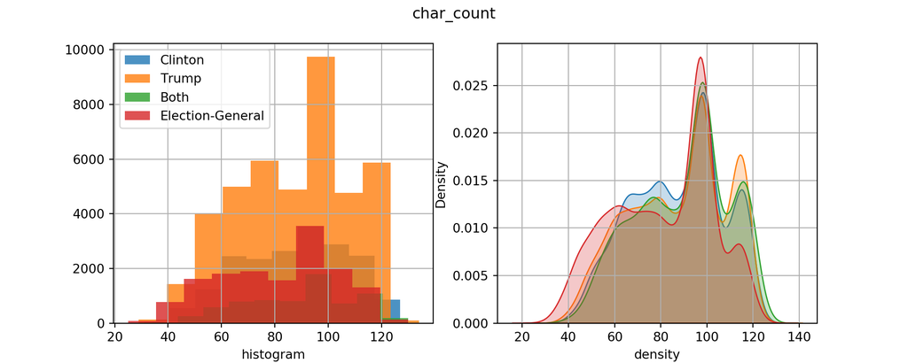

```python
#### Plot word count stats by keyword
x, y = "char_count", "Keyword"
fig,ax = plot_distribution(df,x,y)
plt.show()
```

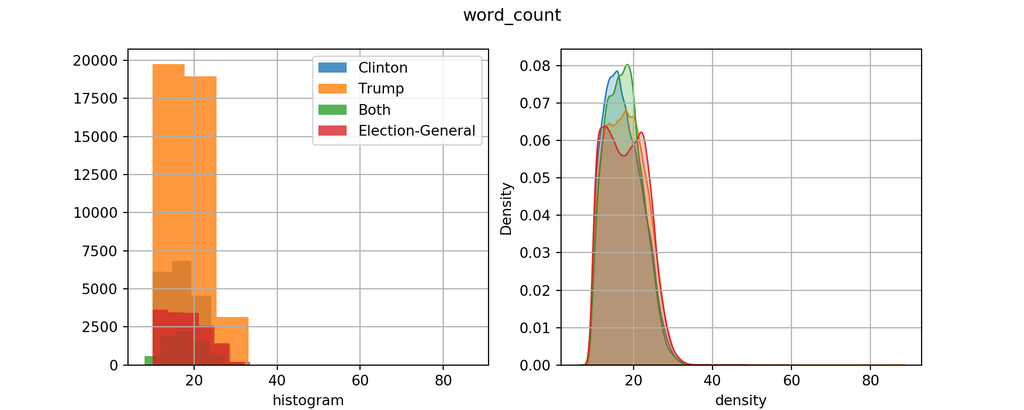

```python
x, y = "word_count", "Keyword"
fig,ax = plot_distribution(df,x,y)
plt.show()
```

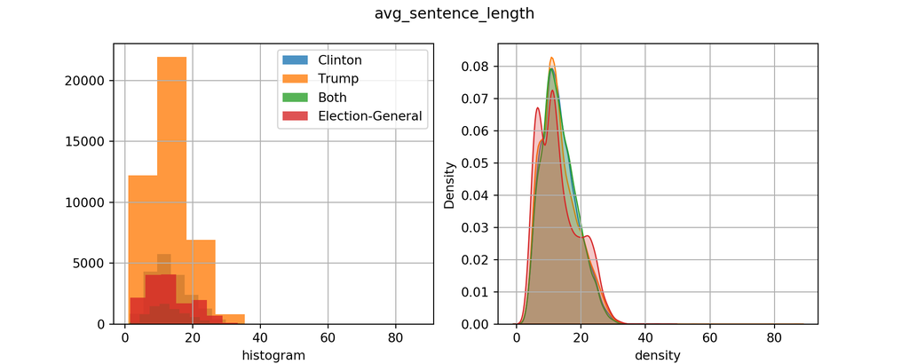

```python
x, y = "avg_sentence_length", "Keyword"
fig,ax = plot_distribution(df,x,y)
plt.show()
```

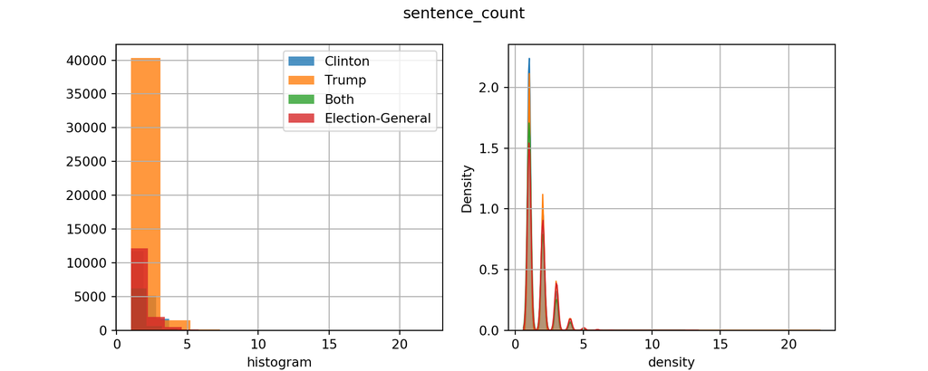

```python
x, y = "sentence_count", "Keyword"
fig,ax = plot_distribution(df,x,y)
plt.show()
```

From the count and density histograms above, even though that the number of tweets talking about Trump is much more than those talking about Clinton, the density histogram shows similarity on the character/word/sentence statistics.

#### Sentiment analysis

```python
#use vader instead of TextBlob
analyzer = SentimentIntensityAnalyzer()
df["sentiment_vader"] = df['Text_Clean'].apply(lambda x:analyzer.polarity_scores(x)['compound'])
df.head(3)
```

```
##    Keyword           Handle  ... avg_sentence_length  sentiment_vader
## 0  Clinton     CrabbyAbbey1  ...                 8.0           0.5859
## 1  Clinton  Marianne_Summer  ...                11.0           0.0000
## 2    Trump        SAcurrent  ...                11.0           0.2500
##
## [3 rows x 14 columns]
```

##### Overall sentiment by keyword

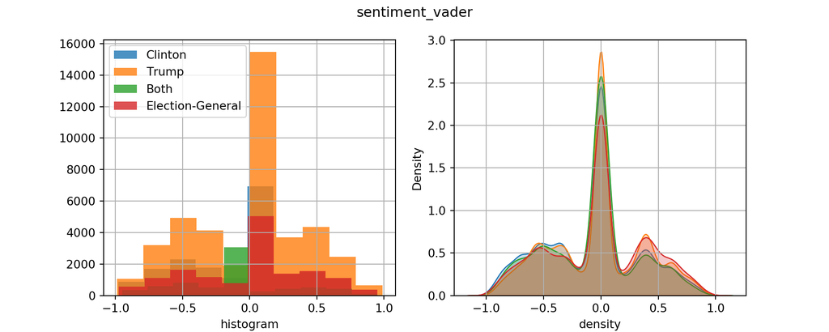

```python
sentiment_col = "sentiment_vader"
# check the distribution of the compound score by keyword
x, y = sentiment_col, "Keyword"
fig,ax = plot_distribution(df,x,y)
plt.show()
```

The density histograms show that it’s mostly centered on score of 0, although it does seem that there’re more negative scores ranged from -0.4 ~ -1 than those postive scores ranged from 0.4 to 1.

```python
# check the overall sentiment stats by keyword
df.groupby('Keyword')[sentiment_col].describe()
```

```
##                     count      mean       std  ...  50%     75%     max
## Keyword                                        ...
## Both               7051.0 -0.072934  0.389990  ...  0.0  0.0000  0.9509
## Clinton           18999.0 -0.085216  0.410470  ...  0.0  0.0772  0.9451
## Election-General  14734.0 -0.019972  0.424616  ...  0.0  0.3182  0.9517
## Trump             41861.0 -0.034949  0.405138  ...  0.0  0.2263  0.9887
##
## [4 rows x 8 columns]
```

We can see that Clinton has a mean score of -0.08 compared to Trump -0.03. So both are overall negative, which is consistent with the previous density histogram. Also it seems that Clinton had a more negative overall sentiment than Trump. Next, I’ll do a t test to see if the difference is statistically significant.

```python
# t test on whether there's difference on the sentiment of Trump VS Clinton
# Assuming equal population variance
print(stats.ttest_ind(df.loc[df['Keyword']=='Trump',sentiment_col],df.loc[df['Keyword']=='Clinton',sentiment_col]))
```

```
## Ttest_indResult(statistic=14.12535432082424, pvalue=3.1255585585655863e-45)
```

So the p value for the test is 3e-45 < 0.05, meaning that there is statistical significance between the overall sentiment difference of Clinton VS Trump in the time range. This answered my research question (1) noted above.

##### Sentiment by number of followers

```python
# check whether there is correlation between sentiment and #followers
df[['Followers',sentiment_col]].corr()
```

```
##                  Followers  sentiment_vader
## Followers         1.000000        -0.000941
## sentiment_vader  -0.000941         1.000000
```

```python
# check abs_sentiment
sentiment_col_abs = f'{sentiment_col}_abs'
df[sentiment_col_abs] = abs(df[sentiment_col])
df[['Followers',sentiment_col_abs]].corr()
```

```
##                      Followers  sentiment_vader_abs
## Followers              1.00000             -0.01044
## sentiment_vader_abs   -0.01044              1.00000
```

Both show no correlations overall.

```python
# try to split the users posts by #followers they have
num_followers_list = df.drop_duplicates(subset = 'Handle')['Followers']
q1, q3 = num_followers_list.quantile([.25,.75])
lower_boundary = q1-1.5*(q3-q1)
higher_boundary = q3+1.5*(q3-q1)
print(lower_boundary,higher_boundary)
```

```
## -1852.0 3292.0
```

```python
# make custom groups by #followers
df['group'] = '<1k followers'
df.loc[df['Followers']>=1e3,'group'] = '1k~100k followers'
df.loc[df['Followers']>=1e5,'group'] = '>=100k followers'

df.groupby(['group'])[sentiment_col].describe().sort_values(by='count',ascending=False)
```

```
##                      count      mean       std  ...  50%     75%     max
## group                                           ...
## <1k followers      54028.0 -0.041714  0.414661  ...  0.0  0.2500  0.9887
## 1k~100k followers  27925.0 -0.057420  0.399260  ...  0.0  0.1280  0.9584
## >=100k followers     692.0 -0.048170  0.388196  ...  0.0  0.0772  0.8316
##
## [3 rows x 8 columns]
```

```python
df.groupby(['group'])[sentiment_col_abs].describe().sort_values(by='count',ascending=False)
```

```
##                      count      mean       std  ...     50%     75%     max
## group                                           ...
## <1k followers      54028.0  0.310369  0.278123  ...  0.3182  0.5423  0.9887
## 1k~100k followers  27925.0  0.294249  0.275899  ...  0.2960  0.5106  0.9887
## >=100k followers     692.0  0.277983  0.275016  ...  0.2732  0.5106  0.9559
##
## [3 rows x 8 columns]
```

So overall, it seems that the group of users with most followers speaks more towards neutral (abs sentiment score lowest among the three groups). Although since the number of users in this group is much less than the other group, it might have some bias because of that.

```python
# break it down by keyword
df.groupby(['Keyword','group'])[sentiment_col].describe().reset_index().sort_values(by=['Keyword','count'],ascending=[True,False])
```

```
##              Keyword              group    count  ...  50%      75%     max
## 1               Both      <1k followers   4570.0  ...  0.0  0.00000  0.9509
## 0               Both  1k~100k followers   2378.0  ...  0.0  0.00000  0.8934
## 2               Both   >=100k followers    103.0  ...  0.0  0.00000  0.7184
## 4            Clinton      <1k followers  11843.0  ...  0.0  0.10270  0.9451
## 3            Clinton  1k~100k followers   7023.0  ...  0.0  0.02580  0.9217
## 5            Clinton   >=100k followers    133.0  ...  0.0  0.25000  0.8273
## 7   Election-General      <1k followers  10085.0  ...  0.0  0.31820  0.9331
## 6   Election-General  1k~100k followers   4586.0  ...  0.0  0.29600  0.9517
## 8   Election-General   >=100k followers     63.0  ...  0.0  0.39185  0.7650
## 10             Trump      <1k followers  27530.0  ...  0.0  0.27880  0.9887
## 9              Trump  1k~100k followers  13938.0  ...  0.0  0.17790  0.9584
## 11             Trump   >=100k followers    393.0  ...  0.0  0.05160  0.8316
##
## [12 rows x 10 columns]
```

```python
df.groupby(['Keyword','group'])[sentiment_col_abs].describe().reset_index().sort_values(by=['Keyword','count'],ascending=[True,False])
```

```
##              Keyword              group    count  ...      50%      75%     max
## 1               Both      <1k followers   4570.0  ...  0.26905  0.52670  0.9509
## 0               Both  1k~100k followers   2378.0  ...  0.20230  0.49390  0.9493
## 2               Both   >=100k followers    103.0  ...  0.31820  0.58590  0.7579
## 4            Clinton      <1k followers  11843.0  ...  0.31820  0.54230  0.9779
## 3            Clinton  1k~100k followers   7023.0  ...  0.29600  0.52545  0.9698
## 5            Clinton   >=100k followers    133.0  ...  0.20230  0.52670  0.9559
## 7   Election-General      <1k followers  10085.0  ...  0.33610  0.54230  0.9698
## 6   Election-General  1k~100k followers   4586.0  ...  0.31820  0.53995  0.9764
## 8   Election-General   >=100k followers     63.0  ...  0.29600  0.56465  0.7717
## 10             Trump      <1k followers  27530.0  ...  0.31820  0.52670  0.9887
## 9              Trump  1k~100k followers  13938.0  ...  0.29600  0.51060  0.9887
## 11             Trump   >=100k followers    393.0  ...  0.27320  0.47670  0.9260
##
## [12 rows x 10 columns]
```

We can see that Clinton had more negative overall sentiment in the small and middle number of followers group, but receive nearly neutral overall sentiment for the group with large number of followers. For Trump, it’s the opposite, Trump received less negative overall sentiment in the groups with small and middle number of followers, but more negative with the group of large number of followers. The absolute sentiment scores both show less strong overall sentiment with more followers. So it turns out to be the opposite of what Hong and Kim, 2016 found out in 2016 using the twitter data of politicians. These findings answer my research question (2).

#### Topic models

```python
pos = df[df[sentiment_col]>=0.05]
neg = df[df[sentiment_col]<=-0.05]
```

```python
# generate the topic models for each candidate, positive and negative
num_topics = 3

for cat in ("Clinton","Trump"):
  for name,subdf in zip(("pos","neg"),(pos,neg)):
    processed_text = [nltk.word_tokenize(i) for i in subdf.loc[subdf['Keyword']==cat,'Text_Clean']]
    #create a dictionary of the words
    dictionary = gensim.corpora.Dictionary(processed_text)
    #create a TDM
    doc_term_matrix = [dictionary.doc2bow(doc) for doc in processed_text]
    # build lda model
    lda_model_clinton_pos = gensim.models.ldamodel.LdaModel(corpus = doc_term_matrix, #TDM
                                                    id2word = dictionary, #Dictionary
                                                    num_topics = num_topics,
                                                    random_state = 100,
                                                    update_every = 1,
                                                    chunksize = 100,
                                                    passes = 10,
                                                    alpha = 'auto',
                                                    per_word_topics = True)
    # create topic model viz
    vis = gensimvis.prepare(lda_model_clinton_pos, doc_term_matrix, dictionary, n_jobs = 1)
    pyLDAvis.save_html(vis, f'LDA_Visualization_{num_topics}topics_{cat}_{name}.html') ##saves the file
```

##### Topic model 1: Clinton - Negative

[interactive chart not shown]

##### Topic model 2: Clinton - Positive

[interactive chart not shown]

##### Topic model 3: Trump - Negative

[interactive chart not shown]

##### Topic model 4: Trump - Positive

[interactive chart not shown]

From topic model 1, we can see that the first topic include words like “vote”,“american”,“cathol”. Maybe the tweets talking about these are describing in a negative way. The top words for the second topic are “email”,“wikileak”,“wiki”, which makes sense for a model built for negative sentiment. The third topic includes words such as “bill”,“rape”,“victim”, which I think is about the negative event on Bill Clinton.

From topic model 2, the first topic contains top words like “like”,“want”,“support”, which are very positive words. The second topic is similar to the second topic of topic model 1. So I assume that’s people tweeting about the same topics but in a positive way. The third topic of this model contains words like “win”,“obama”,“govern”,“campaign”, which kinds of make sense since obama won the last election as a democratic candidate 4 years ago.

From topic model 3, the first topic just mostly contains the names of the candidates - “donald”,“trump”,“hillari”, so it doesn’t seem to have much information. The second has “republican”,“dont”,“right” and the third contains “talk”,“tape”,“hate”, which makes sense for the negative sentiment.

From topic model 4, the first contains “trump”,“support”,“vote”, which makes sense for a positive sentiment. Second has “like”,“people”,“good”,“president”, which makes sense for a positive sentiment. Third topic contains top words like “gop”,“news”,“ryan”, so some keywords about the republican party.

### Discussion

To summarize the analysis above, from this study, we can conclude that:

1. There is statistical significant difference between the overall sentiment for Clinton VS Trump, where Clinton received more negative sentiment.
2. The number of followers doesn’t show correlation to how strong the sentiment is. However, if we break it up by the keyword, we do find out that the sentiment for Clinton is more neutral when number of followers increased, and the sentiment for Trump is more negative when number of followers increased.
3. The absolute sentiment score decreases when the number of followers increases. So it’s the opposite to the findings by Hong and Kim in 2016 using the twitter data of politicians, where they found out that politicians with more extreme political ideological position will have more twitter followers.
4. The topic models provide some insights on what’s the topics contributing to the positive and negative sentiment for each keyword. Although I found that the topics are kind of similar no matter if it’s positive tweets or negative tweets. So I think there’s not much difference between positive and negative topics, it might simply be the most hot topics and people are tweeting in either positive or negative ways.
5. This study based on the assumption that the vader sentiment model is doing a good job.
6. This is a study based on the unit of tweet. There could be some potential bias on this study (e.g., some people tweets more often than others.) It could be especially biased if those people who tweets more often and that they have a large amount of followers.

A direct and interesting application of this study could be to predict the next presidential election result based on the twitter data right before the election.

### Credit Guidelines

I did this project by myself and thanks for Dr. Kayla Jordan for providing the data and some suggestions.

- Developed Research Question
- Acquired Data
- Analyzed Data
- Researched Related Work
- Wrote Introduction
- Wrote Method
- Wrote Analysis/Results
- Wrote Discussion
- Revisions/Edits

### References

Dahal, B., Kumar, S. A. P., & Li, Z. (2019). Topic modeling and sentiment analysis of global climate change tweets. Social Network Analysis and Mining, 9(1), 1–20. https://doi.org/10.1007/s13278-019-0568-8

Jeong, B., Yoon, J., & Lee, J.-M. (2019). Social media mining for product planning: A product opportunity mining approach based on topic modeling and sentiment analysis. International Journal of Information Management, 48, 280–290. https://doi.org/10.1016/j.ijinfomgt.2017.09.009

Hare, C., & Poole, K. T. (2014). The Polarization of Contemporary American Politics. Polity, 46(3), 411–429. https://doi.org/10.1057/pol.2014.10

Hong, S., & Kim, S. H. (2016). Political polarization on twitter: Implications for the use of social media in digital governments. Government Information Quarterly, 33(4), 777–782. https://doi.org/10.1016/j.giq.2016.04.007

Nguyen, Thien & Shirai, Kiyoaki. (2015). Topic Modeling based Sentiment Analysis on Social Media for Stock Market Prediction. 1. https://doi.org/10.3115/v1/P15-1131